# Redes Neuronales Recurrentes (RNN)

### Entrenamiento del modelo

```python
# Se ajusta con 500 epochs con un tamaño de lote de 1.
modelo.fit(X, y, epochs=500, batch_size=1, verbose=0)
```

```
## <keras.callbacks.History object at 0x7fefa3b2dcd0>
```

### Predicción del modelo

```python
#Vamos a hacer una predicción sobre el dataset de validación y, a partir de ésta,
#generamos la matriz de confusión y mostramos las métricas mencionadas anteriormente:
modelo_pred = modelo.predict(X,verbose=0)
rnn_modelo_predicted = np.argmax(modelo_pred, axis=1)
rnn_modelo_predicted
```

```
## array([ 1,  2,  3,  4,  5,  6,  7,  8,  9, 10, 11, 12, 13, 14, 15, 16, 17,
##        18, 20, 20, 21, 23, 24, 25, 25])
```

### Matriz de confusión

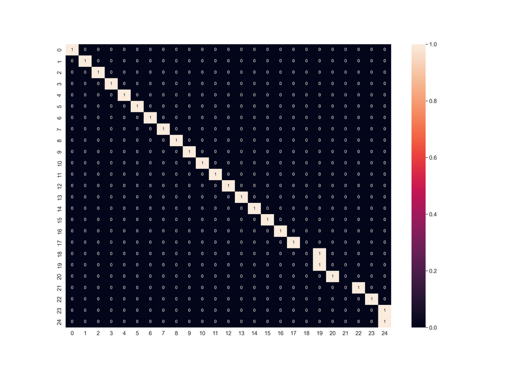

```python
rnn_modelo_cm = confusion_matrix(np.argmax(y, axis=1), rnn_modelo_predicted)

# Visualiamos la matriz de confusión
rnn_modelo_df_cm = pd.DataFrame(rnn_modelo_cm, range(25), range(25))
plt.figure(figsize = (20,14))
sn.set(font_scale=1.4) #for label size
sn.heatmap(rnn_modelo_df_cm, annot=True, annot_kws={"size": 12}) # font size
plt.show()
```

```python
# demuestra la predicciones del modelo
for pattern in dataX:
    x = np.reshape(pattern, (1, len(pattern), 1))
    x = x / float(len(alfabeto))
    prediction = modelo.predict(x, verbose=0)
    index = np.argmax(prediction)
    result = int_to_char[index]
    seq_in = [int_to_char[value] for value in pattern]
    print(seq_in, "->", result)
```

```
## ['A'] -> B
## ['B'] -> C
## ['C'] -> D
## ['D'] -> E
## ['E'] -> F
## ['F'] -> G
## ['G'] -> H
## ['H'] -> I
## ['I'] -> J
## ['J'] -> K
## ['K'] -> L
## ['L'] -> M
## ['M'] -> N
## ['N'] -> O
## ['O'] -> P
## ['P'] -> Q
## ['Q'] -> R
## ['R'] -> S
## ['S'] -> U
## ['T'] -> U
## ['U'] -> V
## ['V'] -> X
## ['W'] -> Y
## ['X'] -> Z
## ['Y'] -> Z
```

```python
# sumariza el rendimiento del modelo
scores = modelo.evaluate(X, y, verbose=0)
print("Precisión del modelo: %.2f%%" % (scores[1]*100))
```

```
## Precisión del modelo: 84.00%
```

# Trabajar con Audio

## Carga audio

### Para cargar un audio vamos a utilizar el paquete `librosa`. Se puede instalar con la siguiente instrucción:

```bash
pip install librosa
```

### Para cargar un audio vamos a utilizar la función `load` e indicamos la ruta del archivo y el número de muestras a obtener por segundo.

```python
import librosa

acorde_mayor,sample_rate = librosa.load("Datos/acorde/mayor/Major_0.wav", sr = 1600)
```

### Con la ayuda de la función `get_duration` podemos obtener la duración en segundos del audio.

```python
librosa.get_duration(acorde_mayor, 1600)
```

```
## 2.25
##
```

### También podemos gráficar el audio con ayuda de `matplotlib` u otro paquete de visualización.

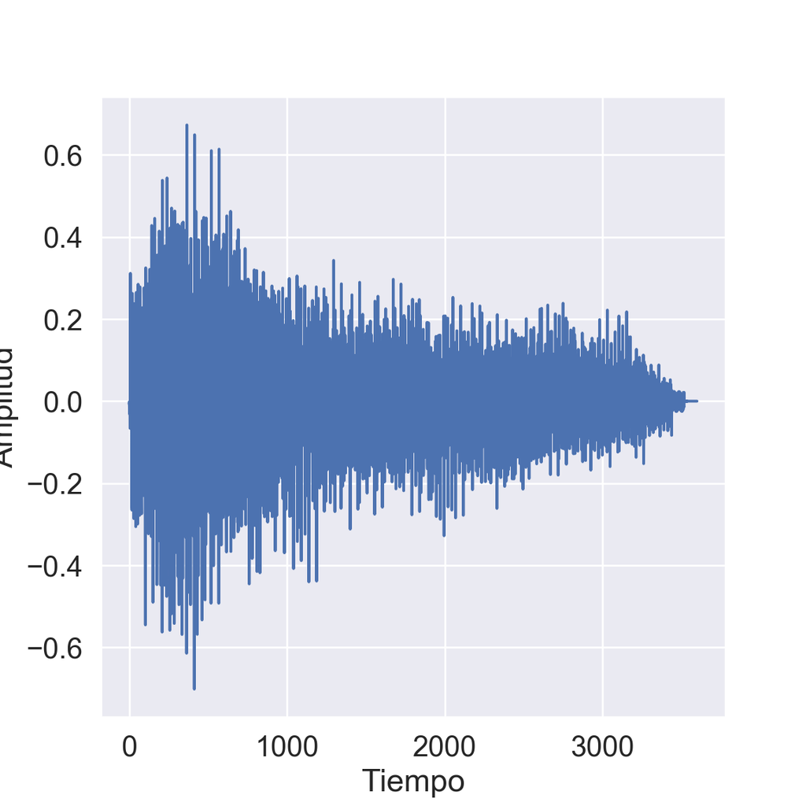

```python
fig, ax = plt.subplots()
ax.plot(acorde_mayor)
ax.set_xlabel('Tiempo')
ax.set_ylabel('Amplitud')
plt.show()
```

### `librosa` nos provee de un conjunto de técnicas las cuales no sirven para obtener características (variables) de un audio, de manera que podamos reducir la cantidad de variables a analizar eliminando aquellas que no aportan o aportan poca información, como por ejemplo ruidos de fondo.

### MFC (Mel Frequency cepstrum): Es una representación del espectro de potencia a corto plazo de un sonido, basado en una transformada de coseno lineal de un espectro de potencia logarítmica en una escala de frecuencia mel no lineal. Es decir, es una transformación matemática que ayuda a procesar el sonido.

```python
mfc = librosa.feature.melspectrogram(y = acorde_mayor, sr= 1600, n_mels = 8)
mfc
```

```
## array([[ 10.694727  ,  15.832964  ,  10.085505  ,   6.1221275 ,
##           4.024767  ,   2.813604  ,   1.4852291 ,   0.19951634],
##        [ 25.061552  ,  44.2976    ,  25.962868  ,  12.742506  ,
##           7.1473484 ,   4.6009197 ,   2.4234383 ,   0.404585  ],
##        [ 54.464363  ,  98.47773   ,  51.71016   ,  22.532825  ,
##          15.731169  ,  12.951301  ,   8.053143  ,   1.9036193 ],
##        [ 53.76316   , 100.05211   ,  43.059673  ,  25.521732  ,
##          31.737226  ,  27.923859  ,  14.668411  ,   2.4513893 ],
##        [ 28.883904  ,  49.108883  ,  21.93658   ,  13.177689  ,
##           9.819499  ,   6.1493006 ,   3.7215219 ,   0.78989196],
##        [ 24.662828  ,  61.62231   ,  47.813847  ,  30.339355  ,
##          20.498371  ,  14.176022  ,   8.736245  ,   2.2263114 ],
##        [ 10.721171  ,  22.201378  ,  14.319867  ,   6.9168186 ,
##           4.739892  ,   3.5851219 ,   2.3669965 ,   0.65106475],
##        [  2.1995087 ,   4.943456  ,   5.1640015 ,   2.9301312 ,
##           1.7370354 ,   0.9681626 ,   0.5541075 ,   0.18894126]],
##       dtype=float32)
```

### MFC MEAN

```python
mfc_mean = np.mean(mfc.T, axis=0)
mfc_mean
```

```
## array([ 6.407305 , 15.330103 , 33.22804  , 37.397194 , 16.698408 ,
##        26.25941  ,  8.187789 ,  2.3356678], dtype=float32)
```

### MFCC (Mel Frequency Cepstral Coefficients): son coeficientes que forman colectivamente un MFC.

```python
mfcc = librosa.feature.mfcc(y = acorde_mayor, sr= 1600, n_mfcc = 8)
mfcc
```

```
## array([[-5.0010002e-01, -2.0952415e+01, -1.8272284e+02, -2.7288773e+02,
##         -2.9453537e+02, -2.4822369e+02, -1.4750446e+02, -1.6225787e+02],
##        [ 4.5938103e+01,  4.0075539e+01,  2.8235737e+01,  4.1545929e+01,
##          4.1697968e+01,  6.3411865e+01,  5.6223553e+01,  4.1034737e+01],
##        [-7.2177536e+01, -7.5975159e+01, -7.2461212e+01, -5.5921715e+01,
##         -5.3587975e+01, -7.3278442e+01, -8.8221222e+01, -8.6822433e+01],
##        [ 2.2845825e+01,  2.4106709e+01,  1.9328960e+01,  2.2459820e+01,
##          2.5569576e+01,  1.8931017e+01,  2.7146259e+01,  2.5561548e+01],
##        [-6.0020142e+01, -6.8011780e+01, -7.7615189e+01, -6.0971260e+01,
##         -5.6349865e+01, -5.6584709e+01, -5.9563934e+01, -5.9449501e+01],
##        [ 1.8525593e+01,  1.9271454e+01,  1.7344318e+01,  6.9026346e+00,
##          5.4790330e+00,  1.2177908e+01,  2.3083000e+01,  2.7814625e+01],
##        [-2.9585999e+01, -3.0217377e+01, -2.9030354e+01, -2.5221687e+01,
##         -2.1825836e+01, -1.2944907e+01, -1.6698647e+01, -1.5724084e+01],
##        [-8.5487264e-01, -1.6086346e-01,  5.2337015e-01, -5.1486158e+00,
##         -9.4262352e+00, -1.5059553e+01, -7.8734484e+00, -3.0885539e+00]],
##       dtype=float32)
```

### MFCC MEAN

```python
mfcc_mean = np.mean(mfcc.T, axis=0)
mfcc_mean
```

```
## array([-166.19806 ,   44.770428,  -72.30571 ,   23.243715,  -62.320797,
##          16.324821,  -22.656113,   -5.136097], dtype=float32)
```

### CHROMA: buscan representar el audio de la música en la que todo el espectro se proyecta en 12 contenedores que representan los 12 semitonos distintos (o croma) de la octava musical.

```python
chroma = librosa.feature.chroma_stft(y = acorde_mayor, sr= 1600, n_chroma = 8)
chroma
```

```
## array([[0.12363202, 0.09184262, 0.04215796, 0.03710213, 0.03635567,
##         0.01917748, 0.022513  , 0.03204024],
##        [0.15465346, 0.14209591, 0.14804836, 0.17305133, 0.15927486,
##         0.12644447, 0.14724521, 0.1665386 ],
##        [1.        , 1.        , 1.        , 1.        , 0.79279053,
##         0.5823242 , 0.70893145, 1.        ],
##        [0.5285455 , 0.5216842 , 0.47360396, 0.4235899 , 0.32216927,
##         0.24133916, 0.31379145, 0.50826615],
##        [0.2901258 , 0.28920582, 0.21659584, 0.17931123, 0.23120254,
##         0.23675638, 0.2782195 , 0.34221017],
##        [0.6680312 , 0.7156495 , 0.6389995 , 0.65943074, 1.        ,
##         1.        , 1.        , 0.97488177],
##        [0.21250372, 0.18980376, 0.13220625, 0.13063592, 0.174649  ,
##         0.15654576, 0.16147144, 0.17183945],
##        [0.80786794, 0.65127736, 0.31497777, 0.2762385 , 0.26764897,
##         0.1397788 , 0.1538334 , 0.18821031]], dtype=float32)
```

### CHROMA MEAN

```python
chroma_mean = np.mean(chroma.T, axis=0)
chroma_mean
```

```
## array([0.05060264, 0.15216902, 0.88550574, 0.41662374, 0.2579534 ,
##        0.83212405, 0.16620691, 0.34997913], dtype=float32)
```

## Ejemplo Acordes de Guitarra

### Para este ejemplo se va a utilizar los datos de acordes los cuales tiene sonidos de acordes de guitarra, donde un acorde es un conjunto de notas que se dividen en mayores y menores, por tanto el objetivo es identificar si el acorde es mayor o menor.

```python
labels = []
audios = []

for carpeta in next(os.walk('Datos/acorde/'))[1]:
  for nombrearchivo in next(os.walk('Datos/acorde/' + '/' + carpeta))[2]:
    if re.search("\\.(mp3|wav|m4a|wma|aiff)$", nombrearchivo):
      try:
        audio, sample_rate = librosa.load('Datos/acorde/' + '/' + carpeta + '/' + nombrearchivo, sr = 1600)
        audio = librosa.feature.mfcc(y = audio, sr = sample_rate, n_mfcc = 128)
        audio = np.mean(audio.T, axis=0)
        audios.append(audio)
        labels.append(carpeta)
      except:
        print("No se pudo cargar el audio: " + nombrearchivo + " en la carpeta: " + carpeta)
```

```python
X = np.array(audios, dtype = np.float32)
y = np.array(labels)
```

```python
print(
  'Total de individuos: ', len(X),
  '\nNúmero total de salidas: ', len(np.unique(y)),
  '\nClases de salida: ', np.unique(y))
```

```
## Total de individuos:  859
## Número total de salidas:  2
## Clases de salida:  ['mayor' 'menor']
```

### Preparación de datos

```python
# Dividir en train y test
train_X, test_X, train_Y, test_Y = train_test_split(X, y, test_size = 0.05)

# Normalizar
scaler = StandardScaler()
sc_training = scaler.fit_transform(train_X)
sc_testing  = scaler.fit_transform(test_X)

# Cambiamos las etiquetas de categoricas a one-hot encoding
train_Y_one_hot = pd.get_dummies(train_Y)
train_Y_one_hot = train_Y_one_hot.to_numpy()

test_Y_one_hot = pd.get_dummies(test_Y)
test_Y_one_hot = test_Y_one_hot.to_numpy()
```

### Estructura de la red

```python
modelo = Sequential()

modelo.add(LSTM(units = 128, input_shape = (128, 1)))
modelo.add(Dense(256, activation = "relu"))
modelo.add(Dense(2, activation = "softmax"))

modelo.compile(loss='binary_crossentropy', optimizer='adam', metrics=['accuracy'])

modelo.summary()
```

```
## Model: "sequential_3"
## _________________________________________________________________
##  Layer (type)                Output Shape              Param #
## =================================================================
##  lstm_1 (LSTM)               (None, 128)               66560
##
##  dense_5 (Dense)             (None, 256)               33024
##
##  dense_6 (Dense)             (None, 2)                 514
##
## =================================================================
## Total params: 100,098
## Trainable params: 100,098
## Non-trainable params: 0
## _________________________________________________________________
```

```python
modelo.fit(train_X, train_Y_one_hot, epochs=50, batch_size=64, verbose=0)

# Guardamos la red, para reutilizarla en el futuro, sin tener que volver a entrenar
```

```
## <keras.callbacks.History object at 0x7fef7fdd7280>
```

```python
modelo.save("lstm_acordes.h5py")
```

```
## WARNING:absl:Found untraced functions such as lstm_cell_1_layer_call_fn, lstm_cell_1_layer_call_and_return_conditional_losses while saving (showing 2 of 2). These functions will not be directly callable after loading.
```

```python
from tensorflow.keras.models import load_model
modelo = load_model('lstm_acordes.h5py')

precision = modelo.evaluate(test_X, test_Y_one_hot, verbose=0)
print(precision[1])
```

```
## 0.7209302186965942
```

### Ejemplo de predicciones

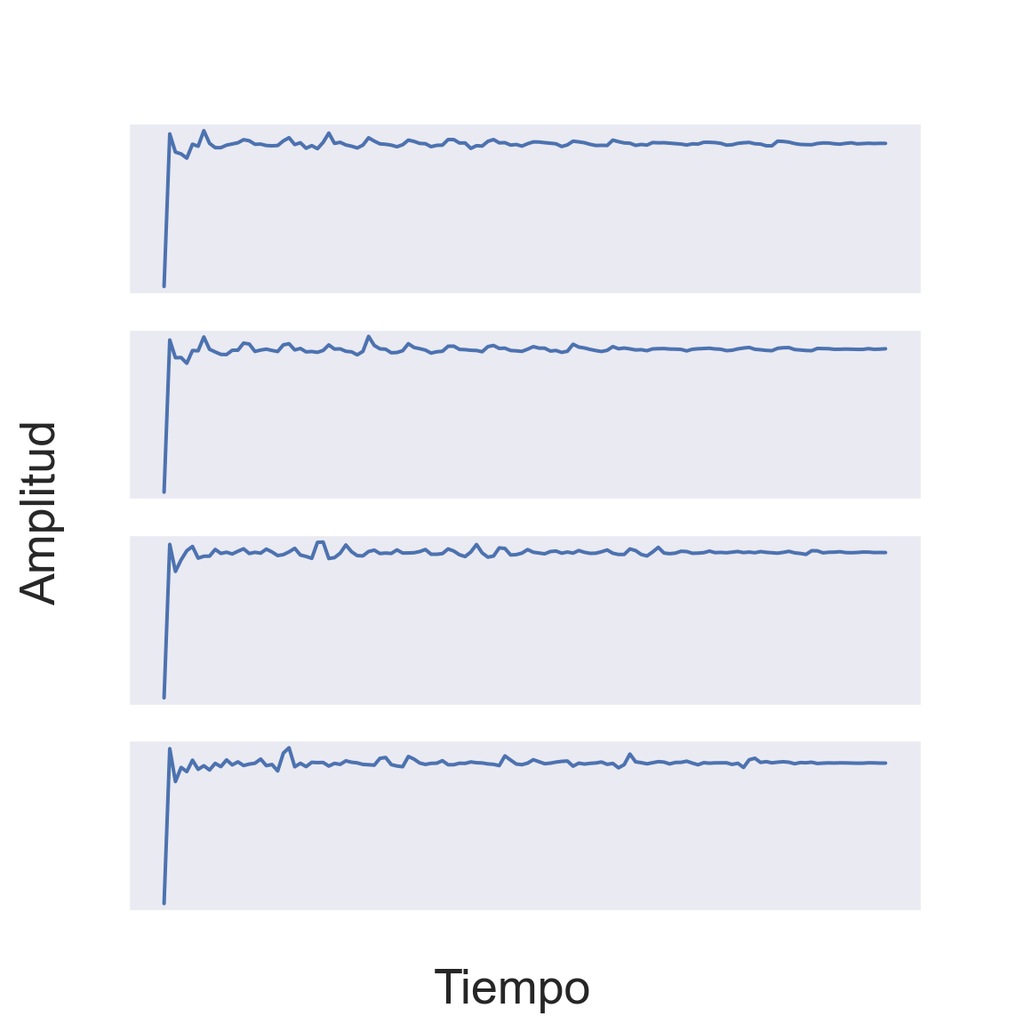

```python
la_mayor,sample_rate = librosa.load("Datos/prueba/la_mayor.wav", sr = 1600)
la_mayor = librosa.feature.mfcc(y = la_mayor, sr= 1600, n_mfcc = 128)
la_mayor = np.mean(la_mayor.T, axis = 0)

la_menor,sample_rate = librosa.load("Datos/prueba/la_menor.wav", sr = 1600)
la_menor = librosa.feature.mfcc(y = la_menor, sr= 1600, n_mfcc = 128)
la_menor = np.mean(la_menor.T, axis = 0)

re_menor,sample_rate = librosa.load("Datos/prueba/re_menor.wav", sr = 1600)
re_menor = librosa.feature.mfcc(y = re_menor, sr= 1600, n_mfcc = 128)
re_menor = np.mean(re_menor.T, axis = 0)

re_mayor,sample_rate = librosa.load("Datos/prueba/re_mayor.wav", sr = 1600)
re_mayor = librosa.feature.mfcc(y = re_mayor, sr= 1600, n_mfcc = 128)
re_mayor = np.mean(re_mayor.T, axis = 0)

audios = np.array([la_mayor, la_menor, re_menor, re_mayor])

fig, ax = plt.subplots(4, 1, figsize=(6, 6), dpi=100)
for i, axi in enumerate(ax.flat):
    axi.set(xticks=[], yticks=[])
    axi.plot(audios[i])

fig.supxlabel('Tiempo')
fig.supylabel('Amplitud')
plt.show()
```

```python
pred = modelo.predict(audios)
print("\nPredicciones: ", np.argmax(pred, axis = 1))
```

```
##
## Predicciones:  [0 1 1 1]
```

```python
print("\nPredicciones: ", np.unique(y)[np.argmax(pred, axis = 1)])
```

```
##
## Predicciones:  ['mayor' 'menor' 'menor' 'menor']
```